# University commute patterns

This visual data story explores patterns in university commute times using observational logging data. Information was collected about transport type, weather conditions, traffic levels, direction of travel, and total commute time.

The purpose of this analysis is to investigate which travel conditions appeared to influence commute times the most, and to communicate these findings using clear and informative visualizations created with {ggplot2}.

## Using the grammar of graphics

The visualisations in this report were created using the layered grammar of graphics approach in {ggplot2}. Variables were mapped to visual elements such as position, colour, and grouping to help communicate patterns in commute behaviour.

## Transport type and commute time

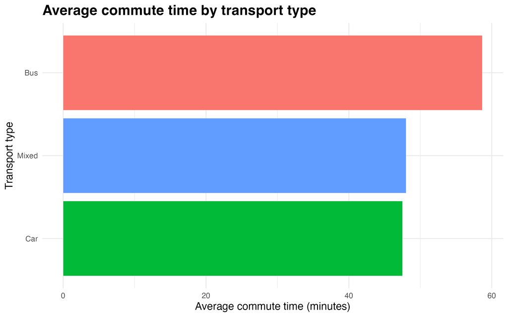

A horizontal bar chart showing average commute time by transport type. Bus has the highest average commute time, while car and mixed transport are slightly lower.

The first visualisation compares average commute time across transport types. This helps show whether some transport options were generally slower than others. In this data, bus trips had the highest average commute time, while car and mixed transport were slightly lower.

## Traffic conditions

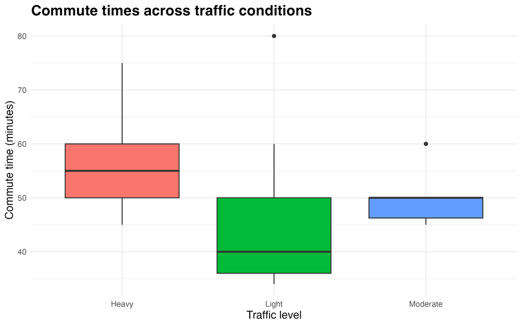

The second visualisation shows how commute times varied across traffic conditions. This graph is useful because it does not only show one average value, but also shows the spread of commute times. Heavy traffic appears to be linked with longer commute times overall.

## Direction, weather, and travel time

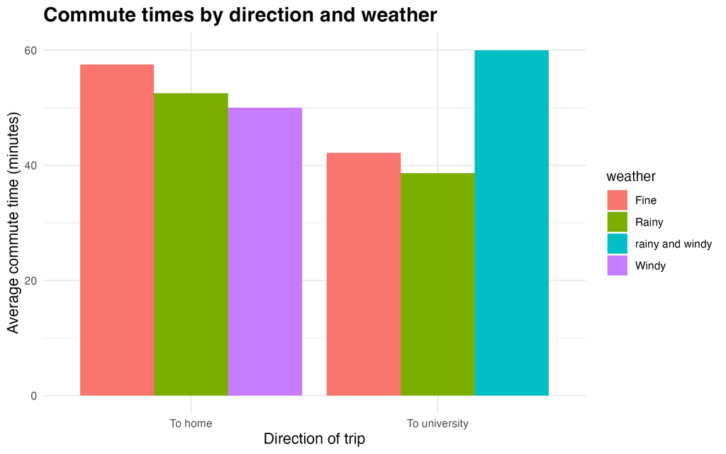

A grouped bar chart showing average commute time by direction and weather. The bars compare trips to university and trips home across weather conditions.

The third visualisation combines direction and weather. This gives a more detailed view of how commute times changed depending on whether the trip was to university or to home, and what the weather was like at the time.

## What the data suggests

Overall, the data suggests that commute time was affected by a combination of transport type, traffic, direction, and weather. The strongest pattern was that heavy traffic and bus trips tended to be linked with longer commute times. This makes sense because traffic delays and public transport schedules can both add extra time to a commute.

The visualisations help tell the story more clearly than a table of numbers because the patterns are easier to compare quickly.